# syll04-belief-oed

mht

August 7, 2014

This is document outlining the design practices behind an experiment aimed to elicit effects of prior knowledge on syllogistic reasoning — so called *belief bias* effects.

We’ve run a model of argument strength with various prior distributions over worlds. We consider 3 distributions for the following analysis:

1. C is a subset of A; B independent
2. A is a subset of C; B independent
3. A, B, C independent

The conclusions for these syllogisms are always **C–A**. These were chosen to match the content used in recent studies of belief bias: Klauer, Musch, and Naumer (2000) and Dube, Rotello, and Heit (2010).

Here are models (1) and (2) plotted against each other: correlation = 0.363

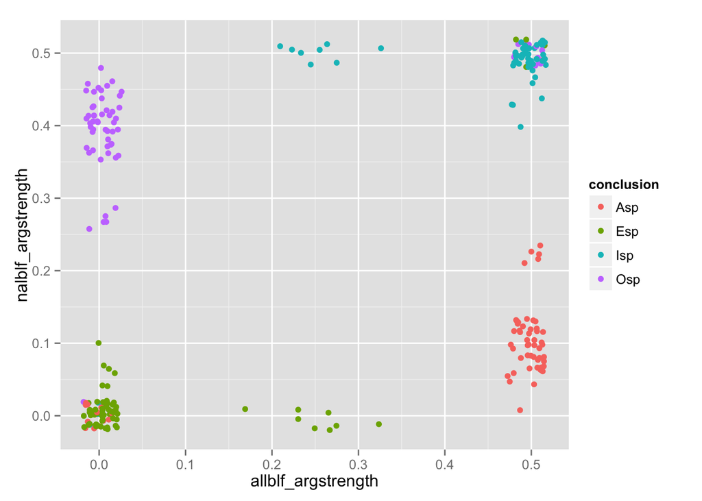

[N.B. a 2% jitter has been added to this plot to reveal more completely overlapping data points e.g. valid conclusions]

It’s clear the the models diverge the greatest on their predictions of the *all* and *not all* predictions, as we would expect with subset relations.

Now, let’s look at each of the belief models vs. the naive model. So let’s call this: (1) vs (3): correlation = 0.2136

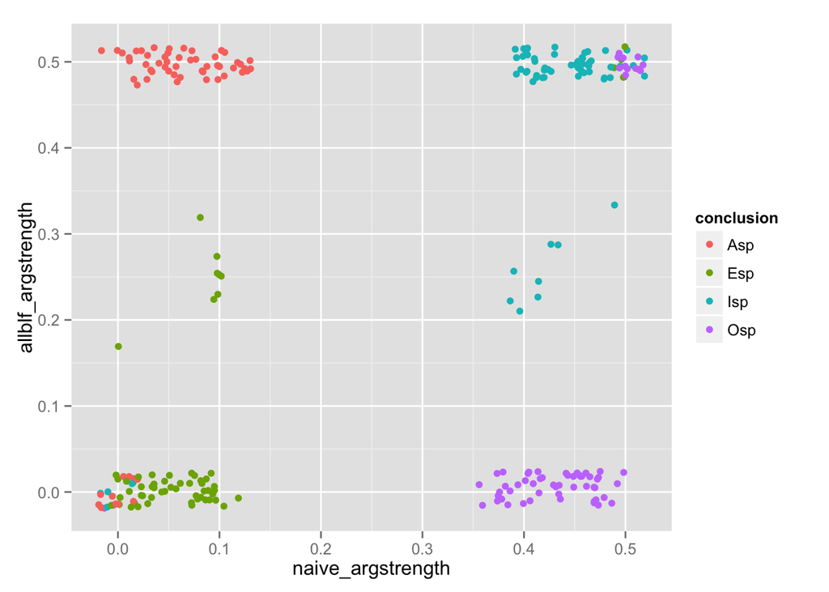

and this one (2) vs (3): correlation = 0.9687

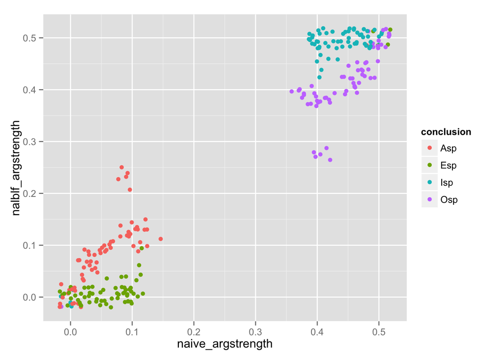

The two “belief” priors yield argument-strength predictions that are not equally as different from the model that uses an independent prior. This is because “belief” prior (2) that A is a subset of C, would often yield the conclusion: *not all Cs are As*, which is same conclusion you often draw when the properties are independent.

Let’s now turn our attention to the syllogisms used in Dube et al. (2010). [N.B. Dube et al. used more syllogisms than those included below. The others ones should be identical in argument strength, but they use A–C conclusion orderings, which we have not modelled here. (but we could very easily)]

Also note that the conclusion to be evaluated, in all cases, was the Osp (not all) conclusion.

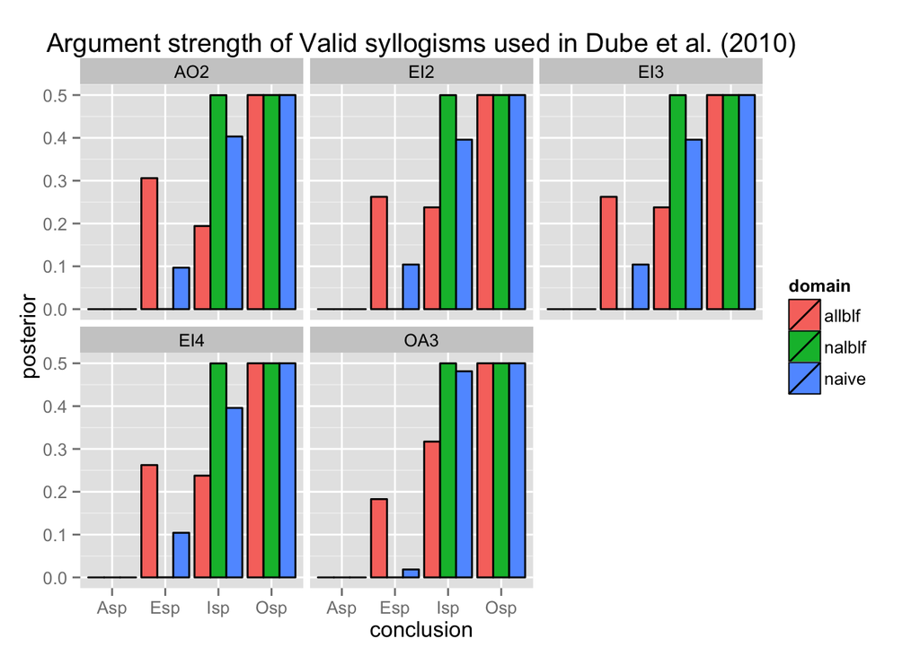

```r
dube.valid = c('EI2','EI3','EI4','AO2','OA3')
dube.invalid = c('IE2','IE3','IE4','EO2','EO3')

tud = 'argstrength'

ggplot(data=subset(m.pred,X..syll%in%dube.valid & type==tud),aes(x=conclusion,y=posterior,fill=domain))+
  geom_bar(stat='identity',position='dodge',color="black")+
  facet_wrap(~X..syll)+
  ggtitle("Argument strength of Valid syllogisms used in Dube et al. (2010)")
```

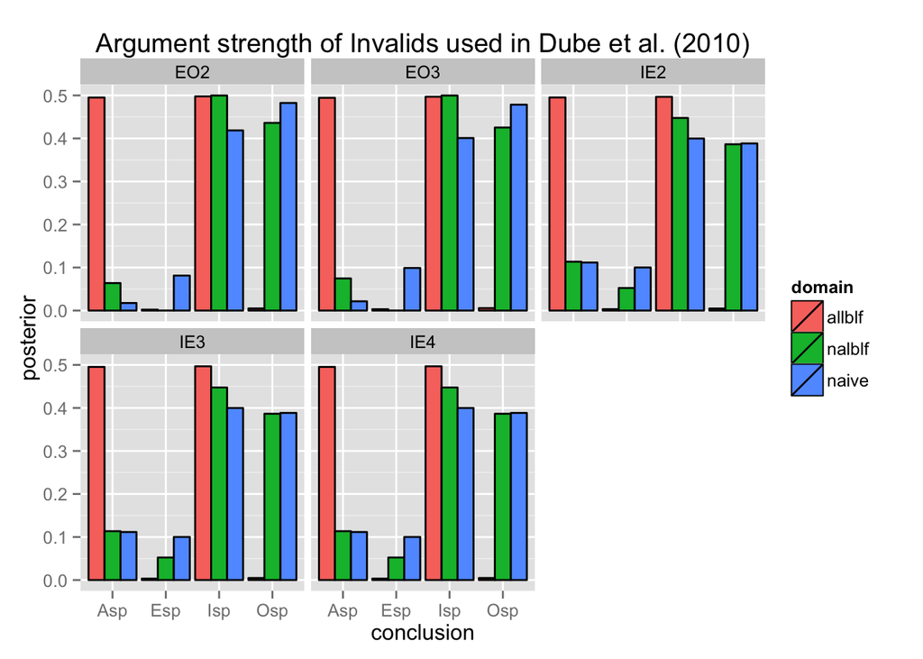

```r
ggplot(data=subset(m.pred,X..syll%in%dube.invalid & type==tud),aes(x=conclusion,y=posterior,fill=domain))+
  geom_bar(stat='identity',position='dodge',color="black")+
  facet_wrap(~X..syll)+
  ggtitle("Argument strength of Invalids used in Dube et al. (2010)")
```

### OED on belief and logic

I ran an OED to try to discriminate three models:

1. argument-strength strong belief 1 – All robins (C) are birds (A)
2. argument-strength naive – A, B, C independent
3. conclusion-only strong belief 1

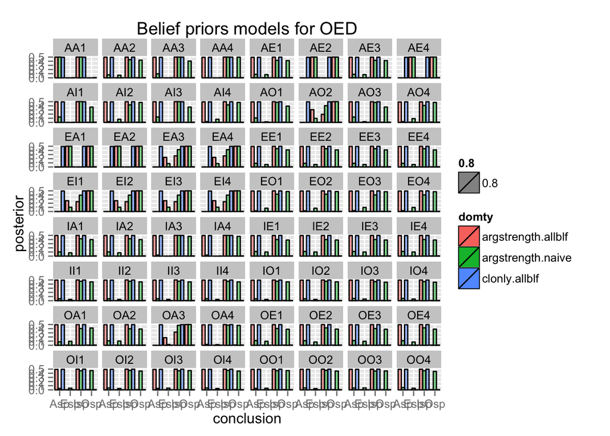

```r
oed <- read.table('/Users/mht/Documents/research/syllogism/models/modeldata/oed_naiveArgStr_beliefArgStr_beliefCLonly_sorted.txt')

ggplot(data=subset(m.pred,X..syll%in%oed[1:64,1] &
              domty%in%c('argstrength.allblf',
                         'argstrength.naive',
                         'clonly.allblf',
                         'clonly.anive')),
       aes(x=conclusion,y=posterior,fill=domty,alpha=0.8))+
  geom_bar(stat='identity',position=position_dodge(),color="black")+
  facet_wrap(~X..syll)+
  ggtitle("Belief priors models for OED")
```

For the “causal” priors (first: the “prevent” priors)

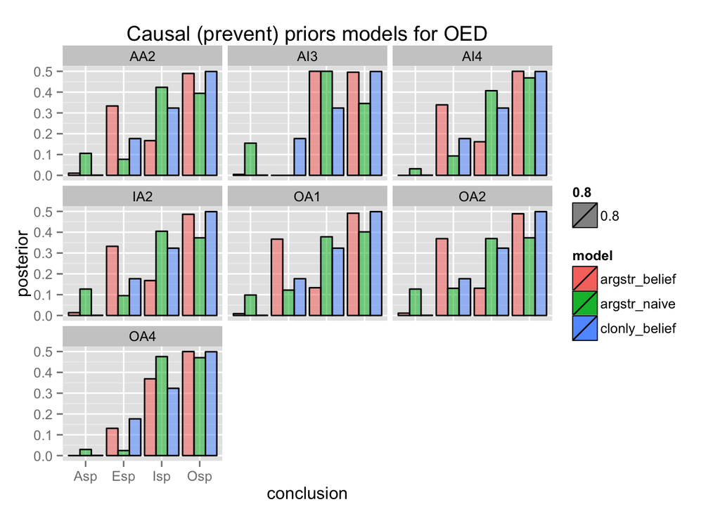

```r
in.c <-read.csv('/Users/mht/Documents/research/syllogism/data/03belief_tests/causal_naive_argstr_clonly.csv')[2:7]

c.pred<-melt(in.c, id.vars=c("X..syll","model"),value.name='posterior',variable.name='conclusion')

c.oed <- read.table('/Users/mht/Documents/research/syllogism/models/modeldata/oed_preventArgStr_naiveArgStr_preventCLonly_sorted.txt')

selection = c("AA2","IA2","OA2","OA1","AI4","OA4","AI3")
#selection = c.oed[1:64,1]
ggplot(data=subset(c.pred,X..syll%in%selection),
       aes(x=conclusion,y=posterior,fill=model,alpha=0.8))+
  geom_bar(stat='identity',position=position_dodge(),color="black")+
  facet_wrap(~X..syll)+
  ggtitle("Causal (prevent) priors models for OED")
```

This selection seems well posed. A more challenging test to disambiguate the models would be if the distributions have the same marginal probabilities. Using the causal-prevent priors above, I generated a distribution with independent properties that have the same marginal distribution. This turns to be roughly P(A)=P(B)=0.3, P(C)=0.7.

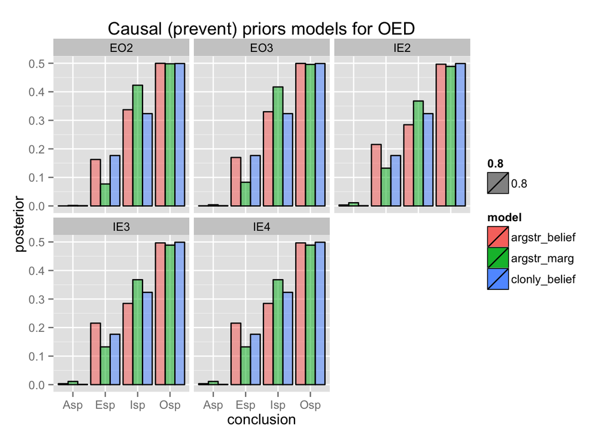

```r
in.cm <-read.csv('/Users/mht/Documents/research/syllogism/data/03belief_tests/causal_marg_argstr_clonly.csv')[2:7]

cm.pred<-melt(in.cm, id.vars=c("X..syll","model"),value.name='posterior',variable.name='conclusion')

#cm.oed <- read.table('/Users/mht/Documents/research/syllogism/models/modeldata/oed_preventArgStr_margArgStr_preventCLonly_sorted.txt')

selection = c("AA2","IA2","OA2","OA1","AI4","OA4","AI3")
#selection = c.oed[1:64,1]
ggplot(data=subset(cm.pred,X..syll%in%dube.invalid),
       aes(x=conclusion,y=posterior,fill=model,alpha=0.8))+
  geom_bar(stat='identity',position=position_dodge(),color="black")+
  facet_wrap(~X..syll)+
  ggtitle("Causal (prevent) priors models for OED")
```

### Pragmatics models and belief

** Put off for later… too complicated **

I now turn my attention to how priors affect the pragmatic enrichments of arguments. We’ll look at the 3 models we looked at before: belief, unbelief, and naive.

```r
# tud = 'pragmatics'
#
# ggplot(data=subset(m.pred,X..syll%in%dube.valid & type==tud),aes(x=conclusion,y=posterior,fill=domain))+
#   geom_bar(stat='identity',position='dodge',color="black")+
#   facet_wrap(~X..syll)+
#   ggtitle("Pragmatic endorsement of Valid syllogisms used in Dube et al. (2010)")
#
#
# ggplot(data=subset(m.pred,X..syll%in%dube.invalid & type==tud),aes(x=conclusion,y=posterior,fill=domain))+
#   geom_bar(stat='identity',position='dodge',color="black")+
#   facet_wrap(~X..syll)+
#   ggtitle("Pragmatic endorsement of Invalids used in Dube et al. (2010)")
```